# Mining the Electronic Health Record, Why and How.

4/19/2018

## Abstract

Medical records are now stored electronically, allowing opportunities for research and quality improvement studies that did not exist before. In this talk, I will review the extraction of information into i2b2, a database that is scrubbed of personal identifiers, and will discuss the strengths and limitations of this data compared to other commonly used health care data sets. I will also show a simple example of creating a medical record phenotype and validating it against a tumor registry.

## Do you understand this cartoon?

[figure not shown]

## Before the Electronic Health Record

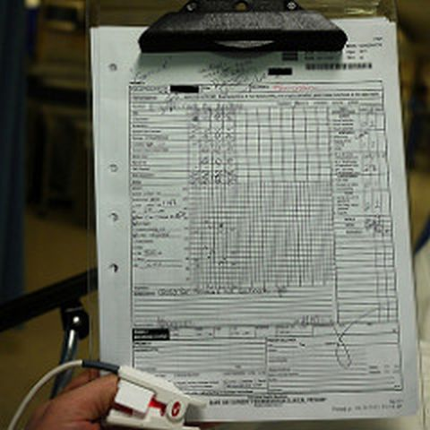

## After the Electronic Health Record

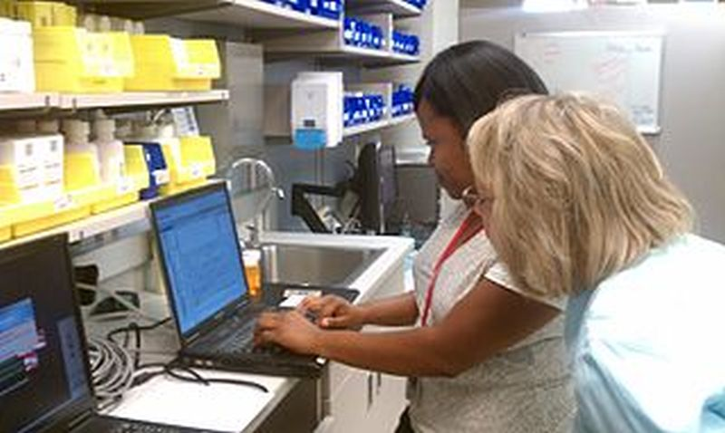

## Mining the EHR, the old way

[figure not shown]

## Mining the EHR with i2b2

[figure not shown]

## What is i2b2?

Acknowledgements: Thanks to Dan Connolly, Mei Liu, Xing Song, and Russ Waitman.

## Do you understand this cartoon?

[figure not shown]

## Before the Electronic Health Record

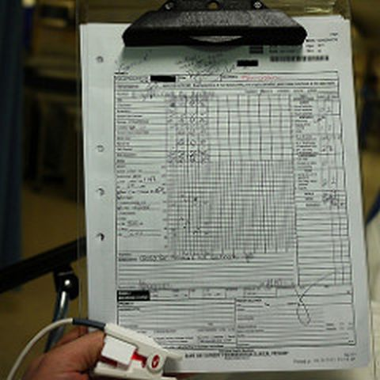

## After the Electronic Health Record

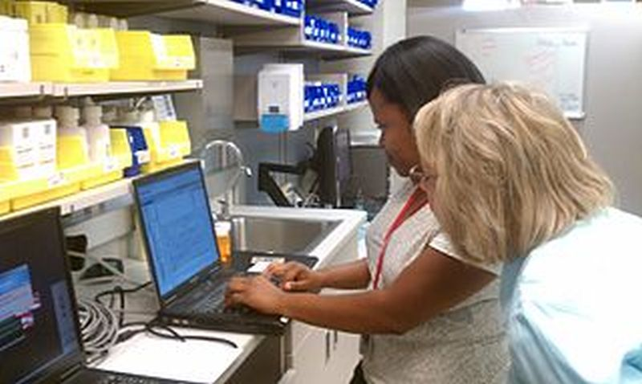

## Mining the EHR, the old way

[figure not shown]

## Mining the EHR with i2b2

[figure not shown]

## What is i2b2?

i2b2 is an acronym:

- Informatics for Integrating Biology and the Bedside.

It has been adopted and aggressively promoted by many hospitals.

## Why not use the source?

You cannot and should not analyze the EHR as it exists within Cerner and Epic because of

- privacy concerns,
- usability issues.

Cerner and Epic are designed for the care needs of individual patients. i2b2, in contrast, is designed for research.

- The data is de-identified.
- You can easily extract groups.
- You can integrate other data sets.

## Intergration example

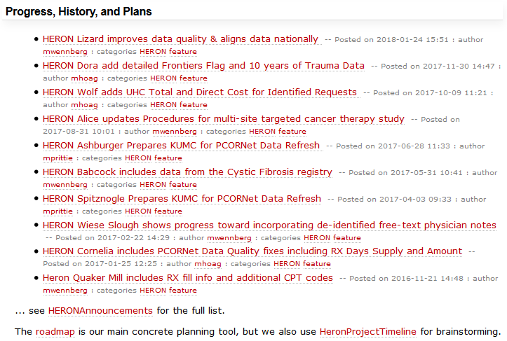

https://informatics.kumc.edu/work/wiki/HERON

## What i2b2 lacks.

i2b2 does not include free text fields (patient notes).

i2b2 does not include information on health care provided to your patients, but provided at other locations.

## Concerns for i2b2 about data quality

"The government [is] extremely fond of amassing great quantities of statistics. These are raised to the nth degree, the cube roots are extracted, and the results are arranged into elaborate and impressive displays. What must be kept ever in mind, however, is that in every case, the figures are first put down by a village watchman, and he puts down anything he damn well pleases."

Attributed to Sir Josiah Stamp, 1840-1941, H.M. collector of inland revenue.

This is a concern, of course, for any secondary data analysis.

## The EAV model

The i2b2 database uses a modified verison of the EAV model. EAV stands for

- Entity
- Attribute
- Value

Longitudinal data has two formats

- "tall and thin" and
- "short and fat".

The EAV model takes "tall and thin" to an extreme.

## An example of a "short and fat" data set

| entity | a1 | a2 | a3 | b1 | b2 | b3 | d1 | d2 | d3 |
| --- | --- | --- | --- | --- | --- | --- | --- | --- | --- |
| alpha | 11 | 21 | 31 | a | c | e | 1-Jan | 1-Feb | 1-Mar |
| bravo | 12 | 22 | 32 | b | d | f | 2-Jan | 2-Feb | 2-Mar |

## … transformed to a "tall and thin" data set

| entity | time | a | b | d |
| --- | --- | --- | --- | --- |
| alpha | 1 | 11 | a | 1-Jan |
| alpha | 2 | 21 | c | 1-Feb |
| alpha | 3 | 31 | e | 1-Mar |
| bravo | 1 | 12 | b | 2-Jan |
| bravo | 2 | 22 | d | 2-Feb |
| bravo | 3 | 32 | f | 2-Mar |

## … transformed into the EAV model

| entity | attribute | value |
| --- | --- | --- |
| alpha | a1 | 11 |
| alpha | b1 | a |
| alpha | d1 | 1-Jan |
| alpha | a2 | 21 |
| alpha | b2 | c |
| … |  |  |

## Another example of the EAV model

```r
# <pt XYZ>, <Temperature in degrees Fahrenheit>, "102"
# <pt XYZ>, <Presence of Cough>, "True"
# <pt XYZ>, <Type of Cough>, "With phlegm, streaks of blood"
# <pt XYZ>, <Heart Rate in beats per minute>, "98"
# ...
```

## Advantages

The advantages of the EAV structure are that

- you are only storing the medications, procedures, and diagnoses that a patient has,
- as new medications, procedures, and diagnoses appear, you can add these without altering the database structure.

The EAV structure is similar to that of a sparse matrix.

Two major concerns

- Querying data in EAV format requires lots of self joins.
- The EAV model demands high quality metadata.

## Self-joins, part 1

Example: Get patients with diabetes diagnosis…

```r
df1 <- dbGetQuery(c_connect,
  "SELECT distinct patient_num
    FROM blueherondata.observation_fact
    WHERE concept_cd LIKE 'ICD9:250%'")
```

## Self-joins, part 2

…and restrict to females only…

```r
df2 <- dbGetQuery(c_connect,
  "SELECT distinct patient_num
    FROM blueherondata.observation_fact
    JOIN (SELECT distinct patient_num AS bc_pt
      FROM blueherondata.observation_fact
      WHERE concept_cd LIKE 'ICD9:250%')
    ON patient_num=bc_pt
    WHERE concept_cd LIKE 'DEM|SEX:f'")
```

## Self-joins, part 3

…and get all medical procedures.

```r
df3 <- dbGetQuery(c_connect,
  "SELECT patient_num, concept_cd
    FROM blueherondata.observation_fact
    JOIN (SELECT distinct patient_num AS female_pt
      FROM blueherondata.observation_fact
      WHERE concept_cd = 'DEM|SEX:f')
    ON patient_num=female_pt
    JOIN (SELECT distinct patient_num AS bc_pt
      FROM blueherondata.observation_fact
      WHERE concept_cd LIKE 'ICD9:250%')
    ON patient_num=bc_pt
    WHERE concept_cd LIKE 'CPT:%'")
```

## The problem with self-joins

It's dangerous to generalize too much, but self-joins are often inefficient.

Joining two separate tables

- if you're lucky, the database can often go down record by record in each table.

Self-joins

- if you're not lucky, the database has to store the entire table in memory.

There are always ways to optimize, of course.

## Metadata

The metadata associated with i2b2 is very important. In particular, the concept path shows the hierarchy associated with medications, procedures, diagnoses, etc.

The metadata also helps with labeling some of the cryptic codes used in the EHR.

## Metadata, diagnoses

Here's an example of the hierarchy for a particular diagnosis.

- concept_cd = ICD10:S35.00XS
- name_char = S35.00XS Unspecified injury of abdominal aorta, sequela
- path level 0 = S35.00 Unspecified injury of abdominal aorta
- path level 1 = S35.0 Injury of abdominal aorta
- path level 2 = S35 Injury of blood vessels at abdomen, lower back and pelvis level
- path level 3 = S30-S39 Injuries to the abdomen, lower back, lumbar spine, pelvis and external genitals
- path level 4 = S00-T88 Injury, poisoning and certain other consequences of external causes
- path level 5 = ICD10

## Metadata, procedures

Here's an example of the hierarchy for a particular procedure.

- concept_cd = CPT:44363
- name_char = Small intestinal endoscopy, enteroscopy beyond second portion of duodenum, not including ileum; with removal of foreign body
- path level 0 = Endoscopy, Small Intestine and Stomal
- path level 1 = Surgical Procedures on the Intestines (except rectum)
- path level 2 = Surgical Procedures on the Digestive System
- path level 3 = Surgical Procedures

## Metadata, medications

Here's an example of the hierarchy for a particular medication.

- concept_cd = KUH|MEDICATION_ID:13878
- name_char = PLENDIL 2.5 MG PO TB24
- path level 0 = Felodipine Extended Release Oral Tablet
- path level 1 = [CV200] CALCIUM CHANNEL BLOCKERS
- path level 2 = [CV000] CARDIOVASCULAR MEDICATIONS

## Metadata, lab tests

Here's an example of the hierarchy for a lab test

- concept_cd = LOINC:3548-5
- name_char = Diazepam SerPl-mCnc (3548-5)
- path level 0 = Diazepam | Bld-Ser-Plas (LP43601-1)
- path level 1 = Diazepam (LP16108-0)
- path level 2 = Benzodiazepines (LP15014-1)
- path level 3 = Tranquilizers (LP30812-9)
- path level 4 = Drugs (LP18046-0)
- path level 5 = Drug/Tox (LP31389-7)

## i2b2 schema

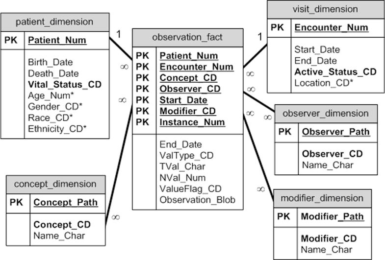

## Alternatives to i2b2, NHAMCS

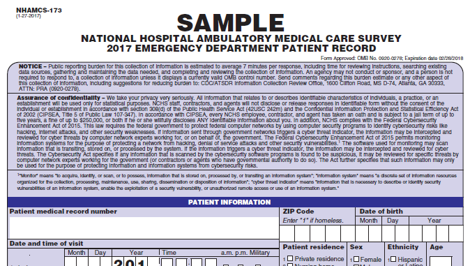

## Alternatives to i2b2, Health facts

[figure not shown]

## Why would you choose i2b2 over these larger nationwide databases?

In many studies, generalizability is a big factor. In those studies, a national database is almost always better than a local database.

A local database, however, still has some advantages.

- It has greater consistency in what data is recorded and how it is recorded.
- It can study local interventions, such as quality improvement studies.
- It can identify how many patients you can recruit for a local prospective trial.

## Application to developing an EHR phenotype

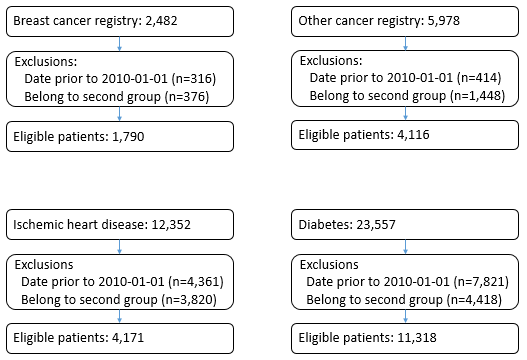

## Application to develop an EHR phenotype

I used an elastic net regression model, a variation of LASSO regression.

## Boxplot of predicted probabilities on a 30% hold-out sample

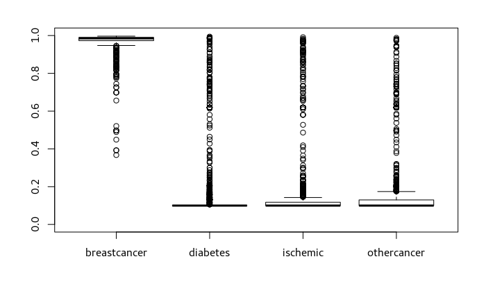

## Other applications, Predicting Acute Kidney Injury.

[figure not shown]

## Further work

My work in this area is just starting. Here are some long term goals.

Expand use of i2b2 at other hospitals in the KC area.

Develop an analytics platform for i2b2.

- Download data directly via SQL.
- Exploit sparse matrix representations.
- Extract information from metadata more easily.

Encourage more statisticians to work in this area.

You can find the source code for this talk at

https://github.com/kumc-bmi/heron-i2b2-analytics/doc/data-mining